# TCRView: Visualizing relationships in a comprehensive reference dataset of paired-chain T cell receptor sequences and epitope specificities

##### All complementarity determining regions (CDRs)

Although not as immensely diverse as the CDR3 region, the remaining CDRs (CDR1, CDR2, and CDR2.5) are still highly diverse and contribute to TCR binding conformations. While commonly assumed that only the CDR3 makes direct contact with epitopes during binding, multiple studies have shown other CDRs to be involved in binding.

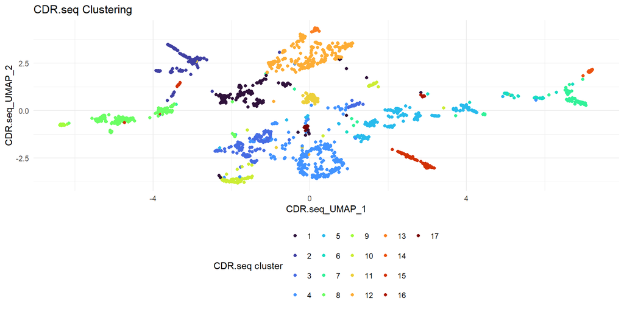

```r
set.seed(77482951)

# CDR clustering
# Combined chains
# Run clustering
# tcr.view.set <- getCDRSeqCluster(tcr.view.set, combine.chains = TRUE, filter.by = filter.by)

# All, colored by cluster (default)
plotCDRSeqClusterResults(tcr.view.set, combine.chains = TRUE, plotly = plotly, filter.by = filter.by, option  = option, begin = begin, end = end)
```

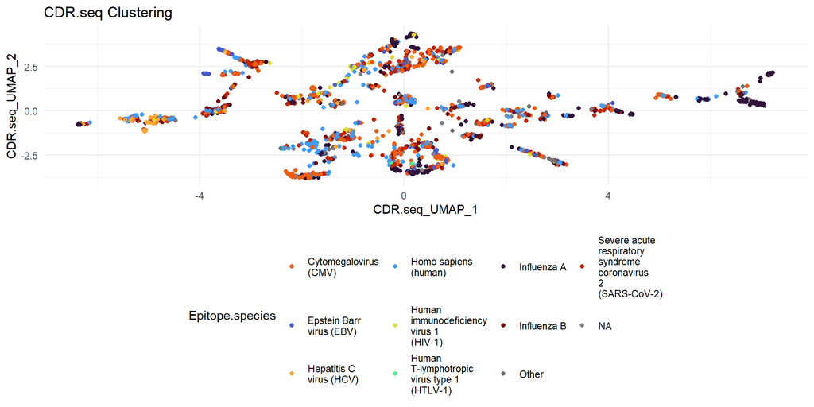

```r
# Top 10 epitope species
plotCDRSeqClusterResults(tcr.view.set, combine.chains = TRUE, top = top, top.col = "Epitope.species", plotly = plotly, filter.by = filter.by, option  = option, begin = begin, end = end)
```

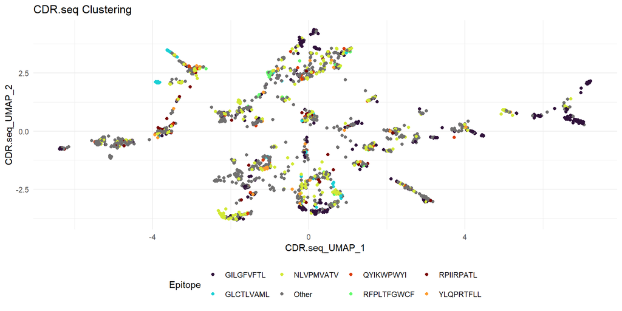

```r
# Receptors from epitopes with > 50 receptors
plotCDRSeqClusterResults(tcr.view.set, combine.chains = TRUE, threshold = 50, threshold.col = "Epitope", plotly = plotly, filter.by = filter.by, option  = option, begin = begin, end = end)
```

[output not shown]

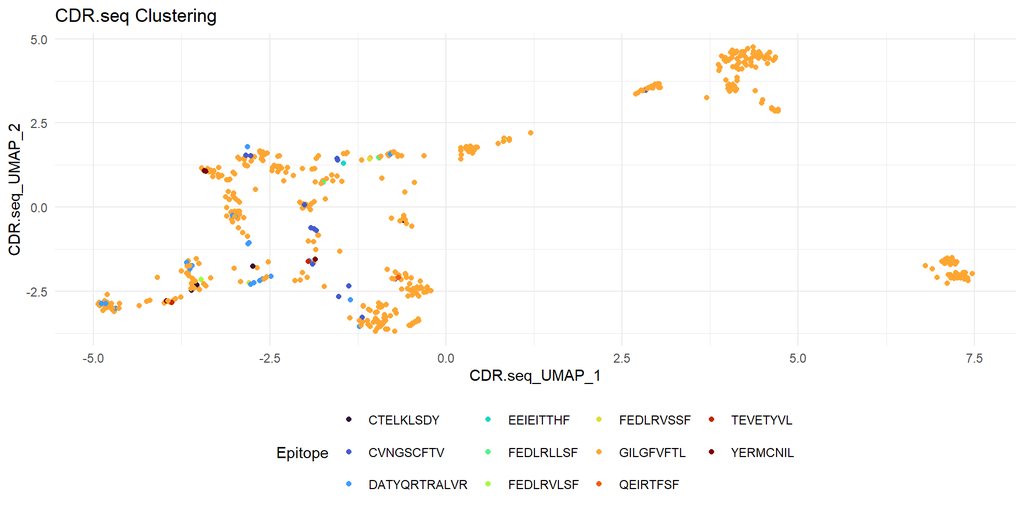

```r
# Receptors limited to SARS-CoV-2 epitopes, colored by epitope
plotCDRSeqClusterResults(tcr.view.set, combine.chains = TRUE, plotly = plotly, filter.by = "Epitope.species == 'Influenza A'", color = "Epitope", option  = option, begin = begin, end = end)
```

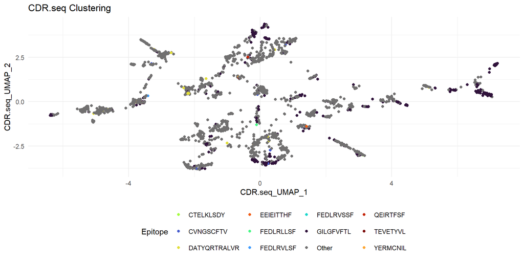

```r
# SARS-CoV-2 epitope, overlaid on all receptors
plotCDRSeqClusterResults(tcr.view.set, combine.chains = TRUE, plotly = plotly, highlight = "Epitope.species == 'Influenza A'", color = "Epitope", option  = option, begin = begin, end = end)
```

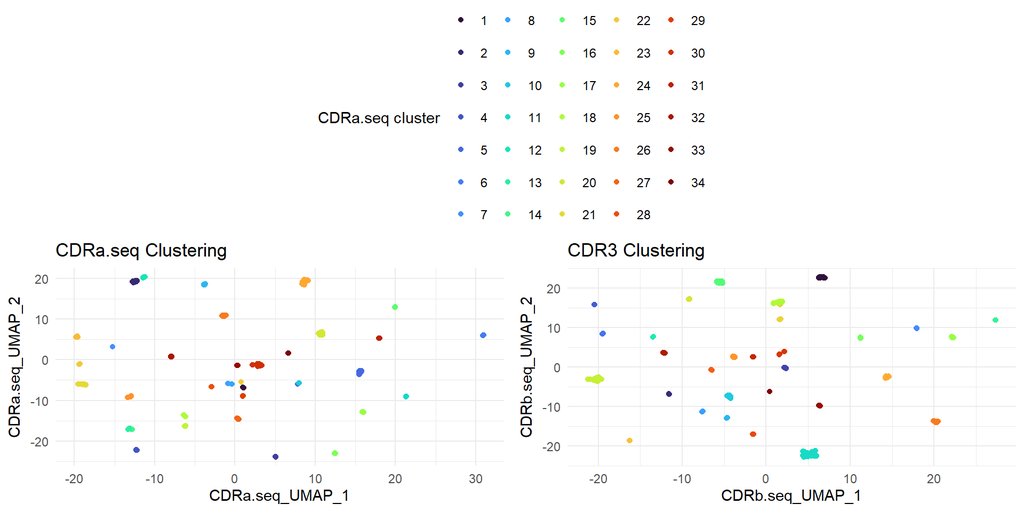

```r
# Per chain
# Run clustering
# tcr.view.set <- getCDRSeqCluster(tcr.view.set, combine.chains = FALSE, filter.by = filter.by)

# All, colored by cluster (default)
plotCDRSeqClusterResults(tcr.view.set, combine.chains = FALSE, plotly = plotly, filter.by = filter.by, option  = option, begin = begin, end = end)
```

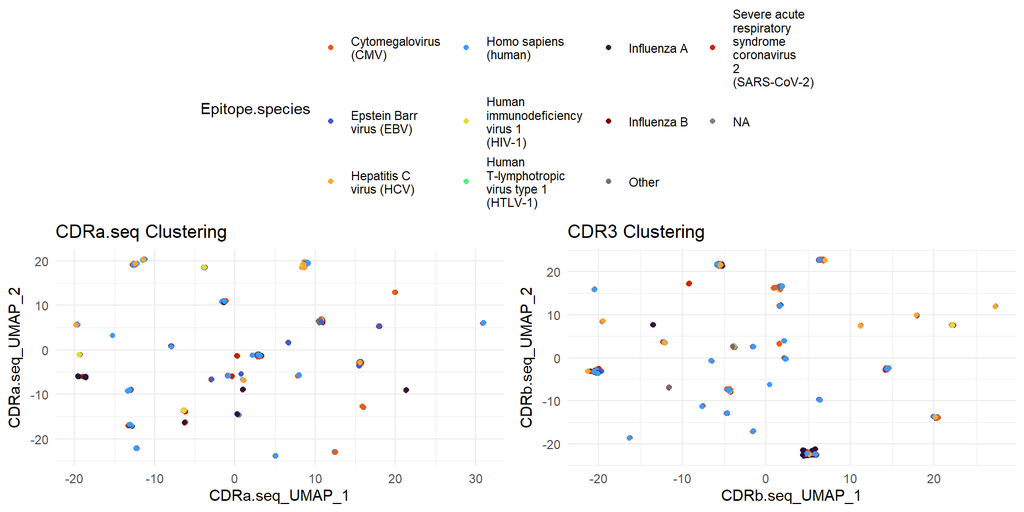

```r
# Top 10 epitope species
plotCDRSeqClusterResults(tcr.view.set, combine.chains = FALSE, top = top, top.col = "Epitope.species", plotly = plotly, filter.by = filter.by, option  = option, begin = begin, end = end)
```

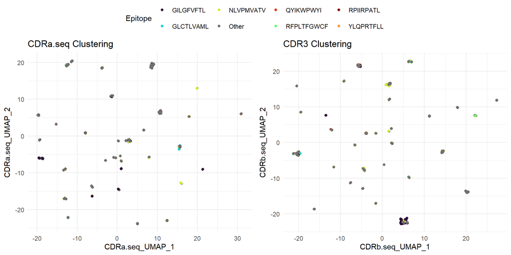

```r
# Receptors from epitopes with > 50 receptors
plotCDRSeqClusterResults(tcr.view.set, combine.chains = FALSE, threshold = 50, threshold.col = "Epitope", plotly = plotly, filter.by = filter.by, option  = option, begin = begin, end = end)
```

[output not shown]

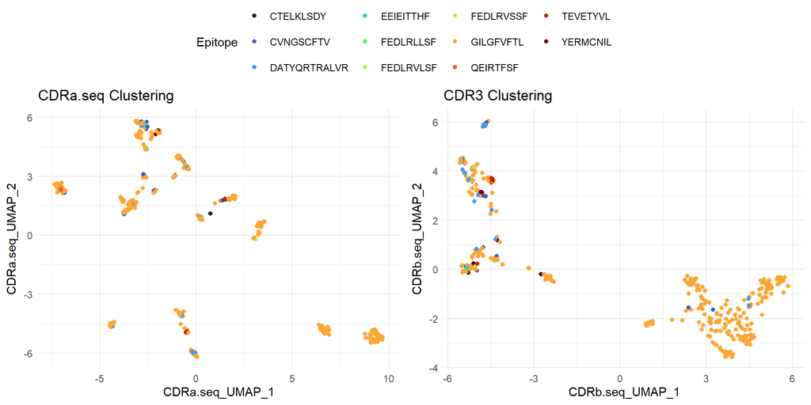

```r
# Receptors limited to SARS-CoV-2 epitopes
plotCDRSeqClusterResults(tcr.view.set, combine.chains = FALSE, plotly = plotly, filter.by = "Epitope.species == 'Influenza A'", color = "Epitope", option  = option, begin = begin, end = end)
```

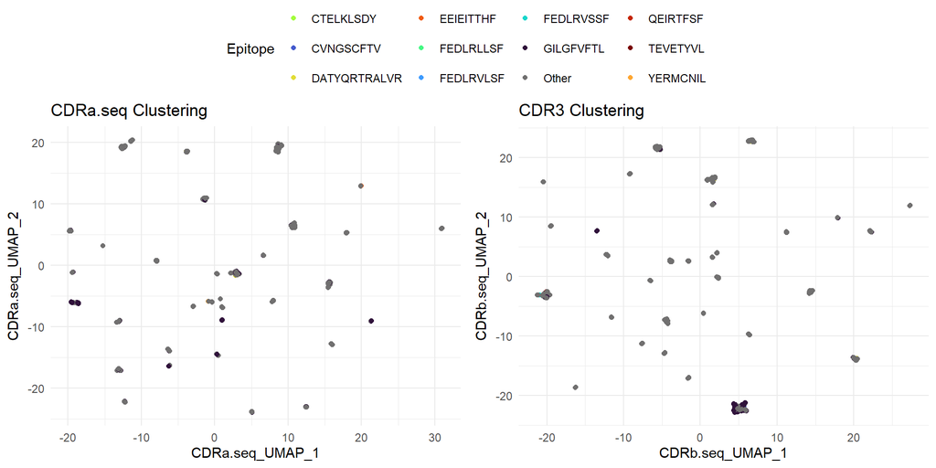

```r
# SARS-CoV-2 epitope, overlaid on all receptors
plotCDRSeqClusterResults(tcr.view.set, combine.chains = FALSE, plotly = plotly, highlight = "Epitope.species == 'Influenza A'", color = "Epitope", option  = option, begin = begin, end = end)
```

##### Full sequence

The full TCR sequence includes the V and J gene segments, the CDRs, and the constant region. The full sequence is important for understanding the complete TCR structure and function, and can provide insight into the diversity of the dataset.

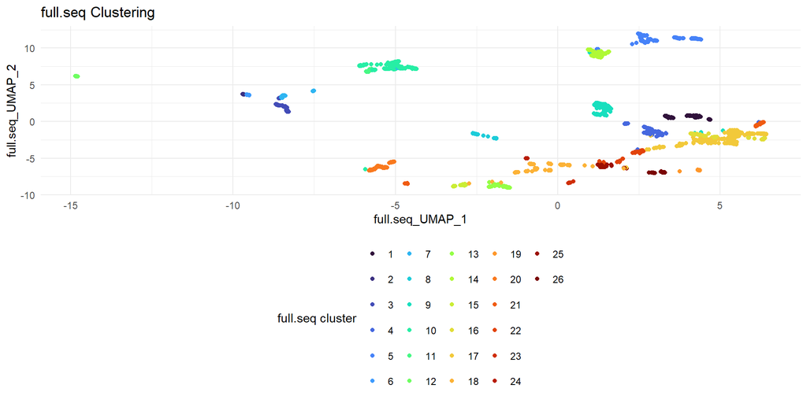

```r
# Full sequence clustering
# Run clustering
# tcr.view.set <- getFullSeqCluster(tcr.view.set, combine.chains = TRUE, filter.by = filter.by)

# All, colored by cluster (default)
plotFullSeqClusterResults(tcr.view.set, plotly = plotly, filter.by = filter.by, option  = option, begin = begin, end = end)
```

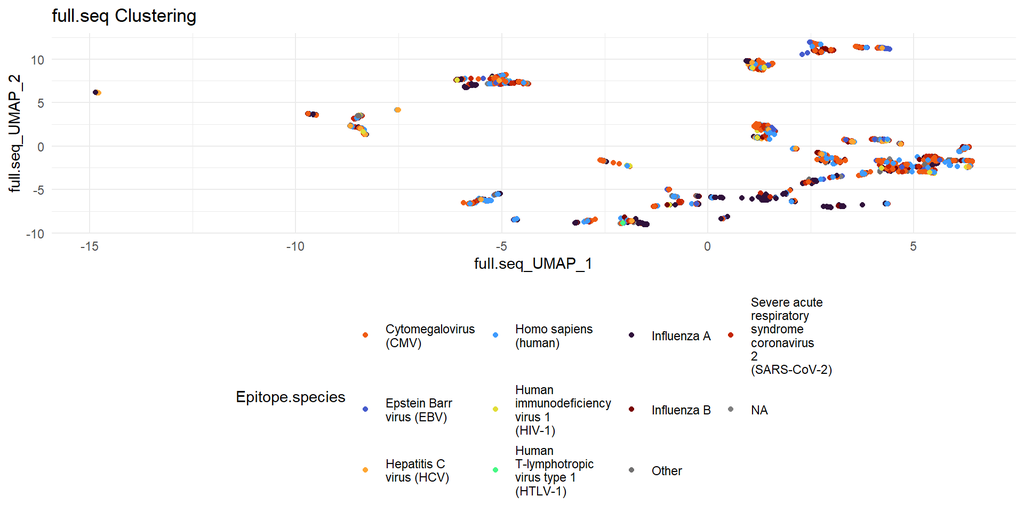

```r
# Top 10 epitope species
plotFullSeqClusterResults(tcr.view.set, top = top, top.col = "Epitope.species", plotly = plotly, filter.by = filter.by, option  = option, begin = begin, end = end)
```

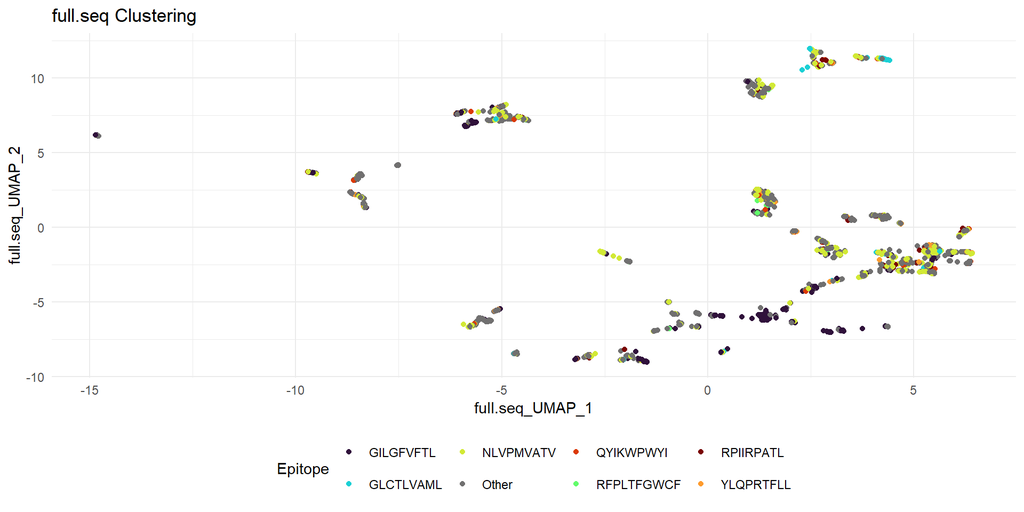

```r
# Receptors from epitopes with > 50 receptors
plotFullSeqClusterResults(tcr.view.set, threshold = 50, threshold.col = "Epitope", plotly = plotly, filter.by = filter.by, option  = option, begin = begin, end = end)
```

[output not shown]

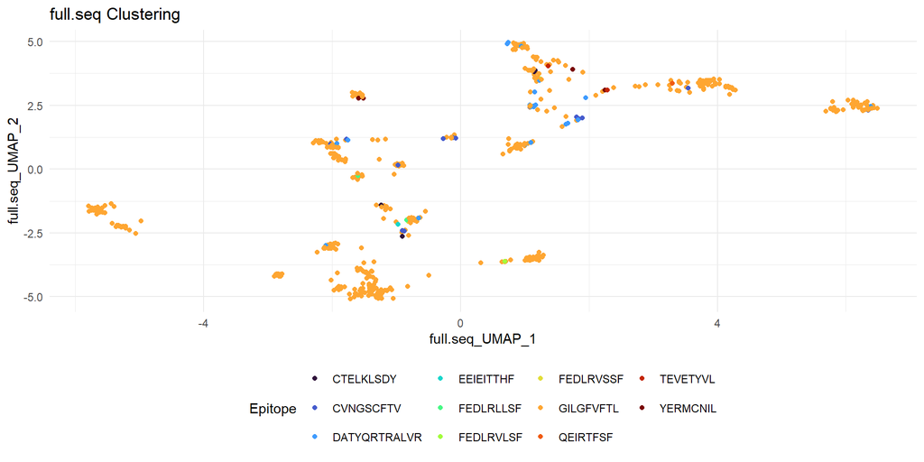

```r
# Receptors limited to SARS-CoV-2 epitopes
plotFullSeqClusterResults(tcr.view.set, plotly = plotly, filter.by = "Epitope.species == 'Influenza A'", color = "Epitope", option  = option, begin = begin, end = end)
```

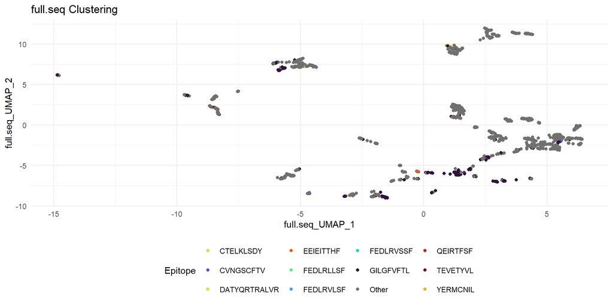

```r
# SARS-CoV-2 epitope, overlaid on all receptors
plotFullSeqClusterResults(tcr.view.set, plotly = plotly, highlight = "Epitope.species == 'Influenza A'", color = "Epitope", option  = option, begin = begin, end = end)
```

```r
if (save) {
    write.csv(tcr.view.set, file = paste0(out.path, "TCRView-data.csv"), row.names = FALSE)
}
```